# Grupo II - Avaliação de indicadores de práticas de saúde em relação a variáveis socioeconômicas

## Práticas Saúde nas escolas X PIB

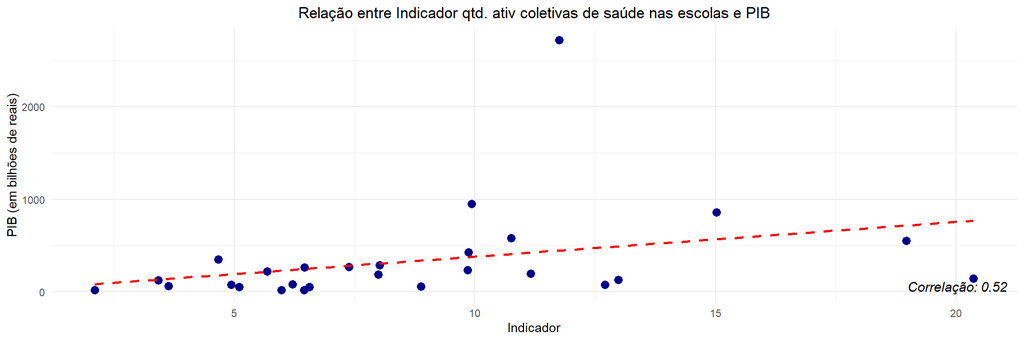

## Práticas Saúde nas escolas X PIB per capita

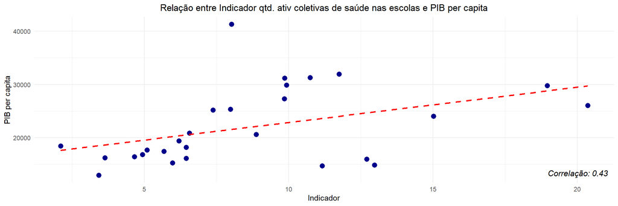

## Práticas Saúde nas escolas X IVS

[figure not shown]

# 5.24 Relação percentual de cobertura acompanhados BF socioeconômicos

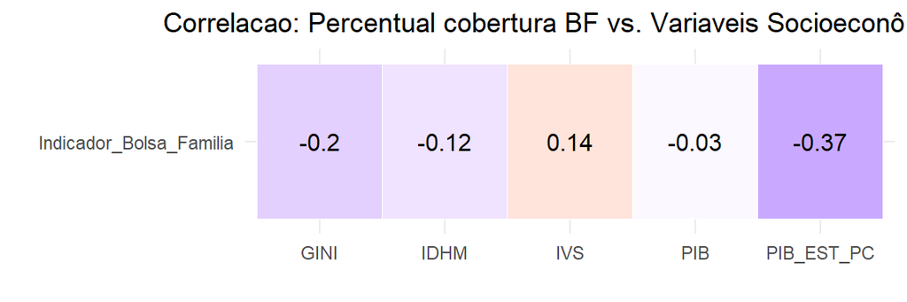

# 5.26 Relação Indicadores cobertura BFA e socioeconômicos

## Cobertura BFA X IDHM

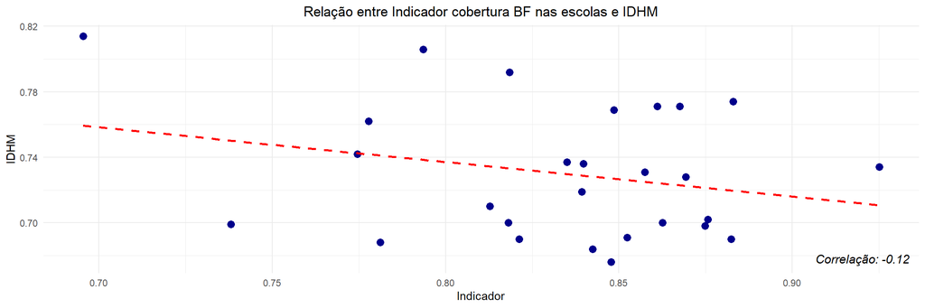

## Cobertura BFA X GINI

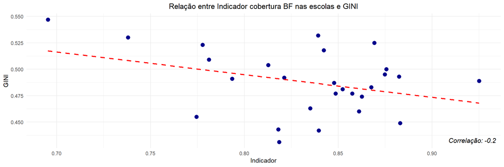

## Cobertura BFA X PIB

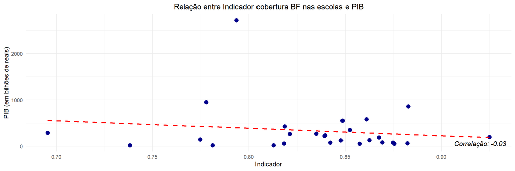

## Cobertura BFA X PIB per Capita

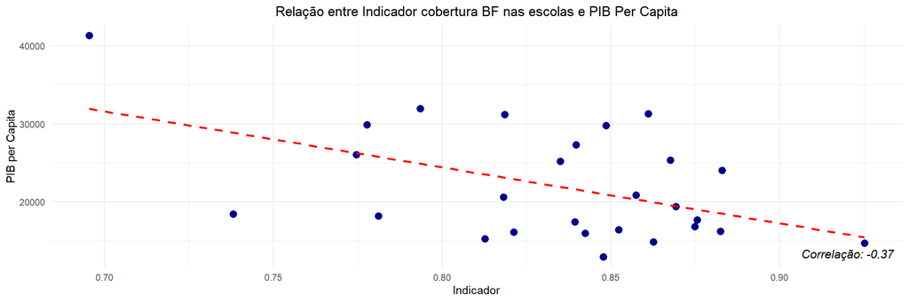

## Cobertura BFA X IVS

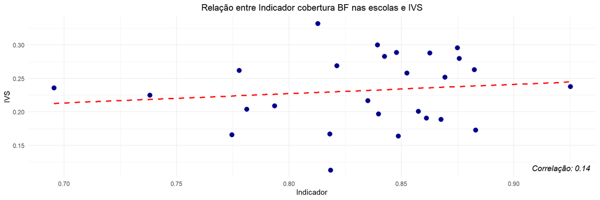

# 5.27 Criação Datasets looker Studio

```r
dataset_correlacao <- rbind(correl_temas_saude, correl_praticas_saude,
                            correl_Bolsa_Familia, correl_adesao_escolas)

dataset_correlacao <- dataset_correlacao %>%
  rename(Desc_Indicador = Indicador)


  #write.xlsx(dataset_correlacao, 'dataset_correlacao.xlsx')
```

```r
dataset_looker_pt1 <- ind_adesão_escolas %>%
  mutate(UF_SIGLA_BR = str_c("BR", UF_SIGLA, sep = "-"))%>%
  select(Pais, IBGE, UF_SIGLA, UF_SIGLA_BR, Municipio_UF, Regiao, ind_Educação, ind_Saúde) %>%
  pivot_longer(cols = c(ind_Educação, ind_Saúde),
               names_to = "Desc_Indicador",
               values_to = "Indicador")

dataset_looker_pt2 <- ind_praticas_saude %>%
  mutate(UF_SIGLA_BR = str_c("BR", UF_SIGLA, sep = "-"))%>%
  select(Pais, IBGE, UF_SIGLA, UF_SIGLA_BR, Municipio_UF, UF_SIGLA,
         Regiao, ind_Antropometria, ind_Praticas_atividades_corporais, ind_Verific_sit_vacina) %>%
  pivot_longer(cols = c(ind_Antropometria, ind_Praticas_atividades_corporais, ind_Verific_sit_vacina),
               names_to = "Desc_Indicador",
               values_to = "Indicador")

dataset_looker_pt3 <- ind_temas_saude %>%
  mutate(UF_SIGLA_BR = str_c("BR", UF_SIGLA, sep = "-"))%>%
  select(Pais, IBGE, UF_SIGLA, UF_SIGLA_BR, Municipio_UF, UF_SIGLA,
         Regiao, ind_Aliment_saudav, ind_saude_bucal, auto_cuid_doenc_cronic,
         ind_Saude_mental, ind_Saude_reprodut) %>%
  pivot_longer(cols = c(ind_Aliment_saudav, ind_saude_bucal, auto_cuid_doenc_cronic,
         ind_Saude_mental, ind_Saude_reprodut),
               names_to = "Desc_Indicador",
               values_to = "Indicador")

dataset_looker_pt4 <- Bolsa_familia_2023 %>%
  mutate(UF_SIGLA_BR = str_c("BR", UF_SIGLA, sep = "-"))%>%
  select(Pais, IBGE, UF_SIGLA, UF_SIGLA_BR, Municipio_UF, Regiao, perc_cob_ben_acomp) %>%
  pivot_longer(cols = c(perc_cob_ben_acomp),
               names_to = "Desc_Indicador",
               values_to = "Indicador")

dataset_looker_pt5 <- bind_rows(
  dataset_looker_pt1,
  dataset_looker_pt2,
  dataset_looker_pt3,
  dataset_looker_pt4
)

dataset_looker_pt6 <- dataset_looker_pt5 %>%
  inner_join(IDHM_Municipios, by = c("IBGE", "UF_SIGLA"))%>%
  select(Pais, IBGE, UF_SIGLA, Municipio_UF, UF_SIGLA_BR, Regiao, Desc_Indicador, Indicador, IDHM_2010)

dataset_looker_pt7 <- dataset_looker_pt6%>%
  inner_join(PIB_PER_CAPITA_MUNICIP, by = c("IBGE", "UF_SIGLA"))

dados_unificados <- dataset_looker_pt7 %>%
  select(Pais, IBGE, UF_SIGLA, Municipio_UF, UF_SIGLA_BR, Regiao, Desc_Indicador, Indicador, IDHM_2010, PIB_per_capita) %>%
  pivot_longer(cols = c(IDHM_2010, PIB_per_capita),
               names_to = "Desc_Indicador_socioeconomico",
               values_to = "Indicador_socioeconomico")

dataset_looker_pt6 <- dataset_looker_pt5 %>%
  inner_join(IDHM_Municipios, by = c("IBGE", "UF_SIGLA"))%>%
  select(Pais, IBGE, UF_SIGLA, Municipio_UF, Regiao, UF_SIGLA_BR, Desc_Indicador, Indicador, IDHM_2010)

dataset_looker_pt7 <- dataset_looker_pt6%>%
  inner_join(PIB_PER_CAPITA_MUNICIP, by = c("IBGE", "UF_SIGLA"))

dados_unificados <- dataset_looker_pt7 %>%
  select(Pais, IBGE, UF_SIGLA, Municipio_UF, Regiao, UF_SIGLA_BR, Desc_Indicador, Indicador, IDHM_2010, PIB_per_capita) %>%
  pivot_longer(cols = c(IDHM_2010, PIB_per_capita),
               names_to = "Desc_Indicador_socioeconomico",
               values_to = "Indicador_socioeconomico")
```

```r
#pasta_destino <- drive_get("Lab_Est")

#drive_upload(
#  media = "dados_unificados.xlsx",       # arquivo local
#  path = pasta_destino,                  # pasta no Drive
#  name = "dados_unificados.xlsx",        # nome do arquivo lá
#  overwrite = TRUE                       # sobrescreve se já existir
#)
```

```r
dataset_looker_ind_escolas <- ind_adesão_escolas %>%
    mutate(UF_SIGLA_BR = str_c("BR", UF_SIGLA, sep = "-"))%>%
  select(UF, Pais, IBGE, UF_SIGLA, UF_SIGLA_BR, Municipio_UF, Regiao, QTD_escolas,
         Educação, Saúde) %>%
  pivot_longer(cols = c(Educação, Saúde),
               names_to = "Desc_Indicador",
               values_to = "Indicador")

#bq_dataset_create(bq_dataset(project = "lab-est", dataset = "Ind_adesao_escolas"))

con <- dbConnect(
  bigquery(),
  project = "lab-est",
  dataset = "Ind_adesao_escolas",
  billing = "lab-est"
)

dbWriteTable(
  con,
  name = "Ind_adesao_escolas",
  value = dataset_looker_ind_escolas,
  overwrite = TRUE
)

dbDisconnect(con)
```

```r
dataset_looker_Prat <- ind_praticas_saude %>%
  mutate(UF_SIGLA_BR = str_c("BR", UF_SIGLA, sep = "-"))%>%
  select(UF, Pais, IBGE, UF_SIGLA, UF_SIGLA_BR, Municipio_UF, Regiao, Antropometria, Praticas_atividades_corporais, Verific_sit_vacina, POP_CADASTRADA_IBGE) %>%
  pivot_longer(cols = c(Antropometria, Praticas_atividades_corporais, Verific_sit_vacina),
               names_to = "Desc_Indicador",
               values_to = "Indicador")

dataset_looker_tem <- ind_temas_saude %>%
  mutate(UF_SIGLA_BR = str_c("BR", UF_SIGLA, sep = "-"))%>%
  select(UF, Pais, IBGE, UF_SIGLA, UF_SIGLA_BR, Municipio_UF, Regiao, Aliment_saudav, Saude_bucal, Saude_mental, Saude_reprodut, auto_cuid_doenc_cronic, POP_CADASTRADA_IBGE) %>%
  pivot_longer(cols = c(Aliment_saudav, Saude_bucal, Saude_mental, Saude_reprodut, auto_cuid_doenc_cronic),
               names_to = "Desc_Indicador",
               values_to = "Indicador")

dataset_looker_prat_tem <- bind_rows(
  dataset_looker_Prat,
  dataset_looker_tem
)
```

```r
#bq_dataset_create(bq_dataset(project = "lab-est", dataset = "Ind_praticas_temas_saude"))

con <- dbConnect(
  bigquery(),
  project = "lab-est",
  dataset = "Ind_praticas_temas_saude",
  billing = "lab-est"
)

dbWriteTable(
  con,
  name = "Ind_praticas_temas_saude",
  value = dataset_looker_prat_tem,
  overwrite = TRUE
)

dbDisconnect(con)
```

```r
dataset_looker_UF_pt1 <- UF_ind_adesao_escolas %>%
  mutate(UF_SIGLA_BR = str_c("BR", UF_SIGLA, sep = "-"),
         Pais = "BR") %>%
  select(Pais, UF_SIGLA, UF_SIGLA_BR, Regiao, Indicador_Educacao, Indicador_Saude, GINI, IVS, IDHM, PIB_EST_PC) %>%
  pivot_longer(cols = c(Indicador_Educacao, Indicador_Saude),
               names_to = "Desc_Indicador",
               values_to = "Indicador") %>%
  pivot_longer(cols = c(GINI, IVS, IDHM, PIB_EST_PC),
               names_to = "Variavel_socioeco",
               values_to = "Valor_socioeco")

dataset_looker_UF_pt2 <- UF_ind_praticas_saude %>%
  mutate(UF_SIGLA_BR = str_c("BR", UF_SIGLA, sep = "-"),
         Pais = "BR") %>%
  select(Pais, UF_SIGLA, UF_SIGLA_BR, Regiao, Indicador_Antropometria,
         Ind_verif_vacina, Ind_Prat_ativ_corp, GINI, IVS, IDHM, PIB_EST_PC) %>%
  pivot_longer(cols = c(Indicador_Antropometria, Ind_verif_vacina, Ind_Prat_ativ_corp),
               names_to = "Desc_Indicador",
               values_to = "Indicador") %>%
  pivot_longer(cols = c(GINI, IVS, IDHM, PIB_EST_PC),
               names_to = "Variavel_socioeco",
               values_to = "Valor_socioeco")

dataset_looker_UF_pt3 <- UF_ind_temas_saude %>%
  mutate(UF_SIGLA_BR = str_c("BR", UF_SIGLA, sep = "-"),
         Pais = "BR") %>%
  select(Pais, UF_SIGLA, UF_SIGLA_BR, Regiao, Indicador_saude_bucal, Indicador_saude_reprodut, Indicador_auto_cuidad, Indicador_saude_mental, Indicador_saude_reprodut,  GINI, IVS, IDHM, PIB_EST_PC) %>%
  pivot_longer(cols = c(Indicador_saude_bucal, Indicador_saude_reprodut, Indicador_auto_cuidad, Indicador_saude_mental, Indicador_auto_cuidad),
               names_to = "Desc_Indicador",
               values_to = "Indicador") %>%
  pivot_longer(cols = c(GINI, IVS, IDHM, PIB_EST_PC),
               names_to = "Variavel_socioeco",
               values_to = "Valor_socioeco")

dataset_looker_UF_pt4 <- UF_ind_Bolsa_Familia%>%
  mutate(UF_SIGLA_BR = str_c("BR", UF_SIGLA, sep = "-"),
         Pais = "BR") %>%
  select(Pais, UF_SIGLA, UF_SIGLA_BR, Regiao, Indicador_Bolsa_Familia,
         GINI, IVS, IDHM, PIB_EST_PC) %>%
  pivot_longer(cols = c(Indicador_Bolsa_Familia),
               names_to = "Desc_Indicador",
               values_to = "Indicador") %>%
  pivot_longer(cols = c(GINI, IVS, IDHM, PIB_EST_PC),
               names_to = "Variavel_socioeco",
               values_to = "Valor_socioeco")

dataset_looker_UF <- bind_rows(
  dataset_looker_UF_pt1,
  dataset_looker_UF_pt2,
  dataset_looker_UF_pt3,
  dataset_looker_UF_pt4
)

dataset_looker_correl <- dataset_looker_UF %>%
  inner_join(dataset_correlacao, by = "Desc_Indicador")%>%
  select(Pais, UF_SIGLA, UF_SIGLA_BR, Regiao, Desc_Indicador, Indicador, Variavel_socioeco, Valor_socioeco, Correlacao)

#bq_dataset_create(bq_dataset(project = "lab-est", dataset = "Correlacao_UF_Indicadores"))

con <- dbConnect(
  bigquery(),
  project = "lab-est",
  dataset = "Correlacao_UF_Indicadores",
  billing = "lab-est"
)

dbWriteTable(
  con,
  name = "Correlacao_UF_Indicadores",
  value = dataset_looker_correl,
  overwrite = TRUE
)

dbDisconnect(con)
```

```r
cor_UF <- dados_unificados %>%
  group_by(UF_SIGLA, Desc_Indicador, Desc_Indicador_socioeconomico) %>%
  summarise(correlacao = cor(Indicador, Indicador_socioeconomico, use = "complete.obs"))%>%
  mutate(nivel = "UF") %>%
  rename(grupo = UF_SIGLA)

cor_regiao <- dados_unificados %>%
  group_by(Regiao, Desc_Indicador, Desc_Indicador_socioeconomico) %>%
  summarise(correlacao = cor(Indicador, Indicador_socioeconomico, use = "complete.obs"))%>%
  mutate(nivel = "Região") %>%
  rename(grupo = Regiao)

cor_brasil <- dados_unificados %>%
  group_by(Desc_Indicador, Desc_Indicador_socioeconomico) %>%
  summarise(correlacao = cor(Indicador, Indicador_socioeconomico, use = "complete.obs"))%>%
  mutate(nivel = "Brasil", grupo = "Brasil")

correlacoes_completas <- bind_rows(cor_UF, cor_regiao, cor_brasil)

# Join por UF
join_uf <- dados_unificados %>%
  left_join(correlacoes_completas %>% filter(nivel == "UF"),
            by = c("UF_SIGLA" = "grupo",
                   "Desc_Indicador",
                   "Desc_Indicador_socioeconomico")) %>%
  mutate(nivel_correlacao = "UF")

# Join por Região
join_regiao <- dados_unificados %>%
  left_join(correlacoes_completas %>% filter(nivel == "Região"),
            by = c("Regiao" = "grupo",
                   "Desc_Indicador",
                   "Desc_Indicador_socioeconomico")) %>%
  mutate(nivel_correlacao = "Região")

# Join Brasil
join_brasil <- dados_unificados %>%
  left_join(correlacoes_completas %>% filter(nivel == "Brasil"),
            by = c("Desc_Indicador", "Desc_Indicador_socioeconomico")) %>%
  mutate(nivel_correlacao = "Brasil")

# Junta tudo
dados_unificados_com_cor <- bind_rows(join_uf, join_regiao, join_brasil)
```

```r
#bq_dataset_create(bq_dataset(project = "lab-est", dataset = "Correlacao_MUNICP_UF_Ind"))

con <- dbConnect(
  bigquery(),
  project = "lab-est",
  dataset = "Correlacao_MUNICP_UF_Ind",
  billing = "lab-est"
)

dbWriteTable(
  con,
  name = "Correlacao_MUNICP_UF_Ind",
  value = cor_brasil,
  overwrite = TRUE
)

dbDisconnect(con)
```

# 6 Referências Bibliográficas

- VIEIRA, Sonia. Bioestatística: Tópicos avançados. 4ª edição. Rio de Janeiro: Elsevier, 2018.
- Heidmann, Ivonete T.S. Buss, Almeida, Maria Cecília Puntel de. Boehs, Astrid Eggert. HEIDMANN, Ivonete T.S.; BUSS, Almeida, Maria Cecília Puntel de; BOEHS, Astrid Eggert; WOSNY, Antonio de Miranda; MONTICELLI, Marisa. Promoção à saúde: Trajetória histórica de suas concepções. Texto Contexto Enferm, v. 15, n. 2, p. 352-358, 2006.
- BUSS, Paulo Marchiori; HARTZ, Zulmira Maria de Araújo; PINTO, Luiz Felipe; ROCHA, Cristianne Maria Famer. Promoção da saúde e qualidade de vida: uma perspectiva histórica ao longo dos últimos 40 anos (1980-2020). Ciência & Saúde Coletiva, v. 25, n. 12, p. 4723-4735, 2020.
- Pinheiro ES, Alcântara CS, Sobral TC, Silva SS, Lima JS, Carvalho DO, et al. Promoção à saúde em serviço de diabetes e hipertensão. REVISA. 2023; 12(Esp1): 671-80.